# Global Disease Burden Analysis

Bienvenu & Fara

# Introduction

The source data is from the Institute for Health Metrics and Evaluation (IHME) Global Burden of Disease (GBD) study.

# Communicable, Maternal, Neonatal, and Nutritional Disease Burden (CMNN)

## Table of Estimates for CMNN Burden Over Time

| Year | Angola | Benin | China |
| --- | --- | --- | --- |
| 1990 | 60834.03 | 46486.57 | 9489.682 |
| 1991 | 59947.46 | 45739.86 | 9320.253 |
| 1992 | 58790.54 | 44593.95 | 9040.871 |
| 1993 | 58131.63 | 43724.30 | 8719.754 |
| 1994 | 57449.72 | 43363.40 | 8439.646 |
| 1995 | 56765.55 | 42832.16 | 7998.544 |
| 1996 | 56124.06 | 42829.97 | 7571.610 |
| 1997 | 55033.19 | 42325.98 | 7181.878 |
| 1998 | 53145.02 | 42088.41 | 6784.139 |
| 1999 | 51554.03 | 41663.56 | 6422.660 |
| 2000 | 50329.27 | 41441.71 | 5995.330 |
| 2001 | 48792.86 | 41199.29 | 5501.361 |
| 2002 | 46979.30 | 40261.63 | 5073.331 |
| 2003 | 45261.28 | 39754.88 | 4646.183 |
| 2004 | 43447.86 | 39052.45 | 4336.731 |
| 2005 | 41554.97 | 38352.29 | 4023.355 |
| 2006 | 39911.41 | 37598.69 | 3702.059 |
| 2007 | 37318.36 | 36817.58 | 3434.673 |
| 2008 | 35110.98 | 35168.62 | 3250.963 |
| 2009 | 33209.46 | 33466.29 | 3082.446 |
| 2010 | 31372.28 | 32388.35 | 2879.783 |
| 2011 | 29892.18 | 31527.01 | 2690.978 |
| 2012 | 28580.45 | 30707.77 | 2528.990 |
| 2013 | 27260.90 | 30150.57 | 2390.026 |
| 2014 | 25792.09 | 29630.13 | 2311.281 |
| 2015 | 24752.86 | 28741.84 | 2229.193 |
| 2016 | 24262.38 | 27954.84 | 2133.682 |
| 2017 | 23424.51 | 27065.90 | 2037.694 |
| 2018 | 22531.07 | 26195.00 | 1959.672 |
| 2019 | 21500.33 | 25070.46 | 1889.165 |

## Plot Showing Trends in CMNN Burden Over Time

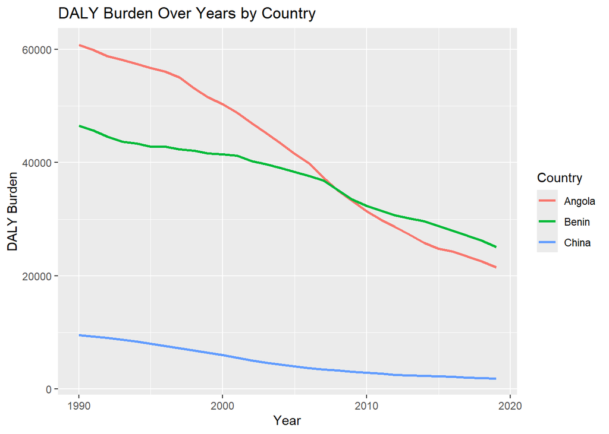

## Summary of CMNN Burden Findings

Globaly, The plot shows a clear decline in DALY burden from 1990 to 2019, indicating improvements in public health and disease control. Angola had the highest burden initially but experienced the steepest reduction, while Benin declined more gradually, and China maintained the lowest burden throughout.

## Attribution

This section was completed by **Bienvenu Kabasele**

The link to the group’s GitHub repository is *https://github.com/bkabaseleilunga-bit/rmc_week_02_workshop*

# Non-Communicable Disease Burden (NCD)

## Table of Estimates for NCD Burden Over Time

| Year | Angola | Benin | China |
| --- | --- | --- | --- |
| 1990 | 28494.81 | 25592.72 | 26899.54 |
| 1991 | 28385.42 | 25535.74 | 26620.36 |
| 1992 | 28364.95 | 25439.81 | 26298.02 |
| 1993 | 28509.21 | 25333.48 | 25968.73 |
| 1994 | 28578.87 | 25379.18 | 25578.53 |
| 1995 | 28331.60 | 25389.34 | 25225.82 |
| 1996 | 27746.26 | 25405.16 | 24890.40 |
| 1997 | 27495.15 | 25254.91 | 24492.28 |
| 1998 | 27680.99 | 25145.00 | 24173.12 |
| 1999 | 27735.27 | 25011.18 | 24025.06 |
| 2000 | 27517.92 | 25005.28 | 23974.24 |
| 2001 | 27098.17 | 24753.36 | 23681.81 |
| 2002 | 26692.32 | 24743.49 | 23420.51 |
| 2003 | 26598.35 | 24480.81 | 23131.23 |
| 2004 | 26728.08 | 24349.45 | 22983.46 |
| 2005 | 26240.29 | 24126.48 | 22531.40 |
| 2006 | 26014.28 | 23995.21 | 21746.74 |
| 2007 | 25621.76 | 23807.42 | 21170.78 |
| 2008 | 25463.46 | 23774.74 | 20850.75 |
| 2009 | 25296.54 | 23854.86 | 20605.98 |
| 2010 | 25141.99 | 23927.69 | 20410.24 |
| 2011 | 24952.80 | 23978.54 | 20090.72 |
| 2012 | 24772.57 | 23940.86 | 19665.65 |
| 2013 | 24458.84 | 23765.69 | 19303.81 |
| 2014 | 23936.19 | 23541.17 | 18996.79 |
| 2015 | 23752.02 | 23513.92 | 18688.31 |
| 2016 | 23497.23 | 23371.82 | 18522.67 |
| 2017 | 23419.30 | 23277.85 | 18354.48 |
| 2018 | 23342.60 | 22851.36 | 18185.74 |
| 2019 | 23277.68 | 22656.17 | 18058.96 |

## Plot Showing Trends in NCD Burden Over Time

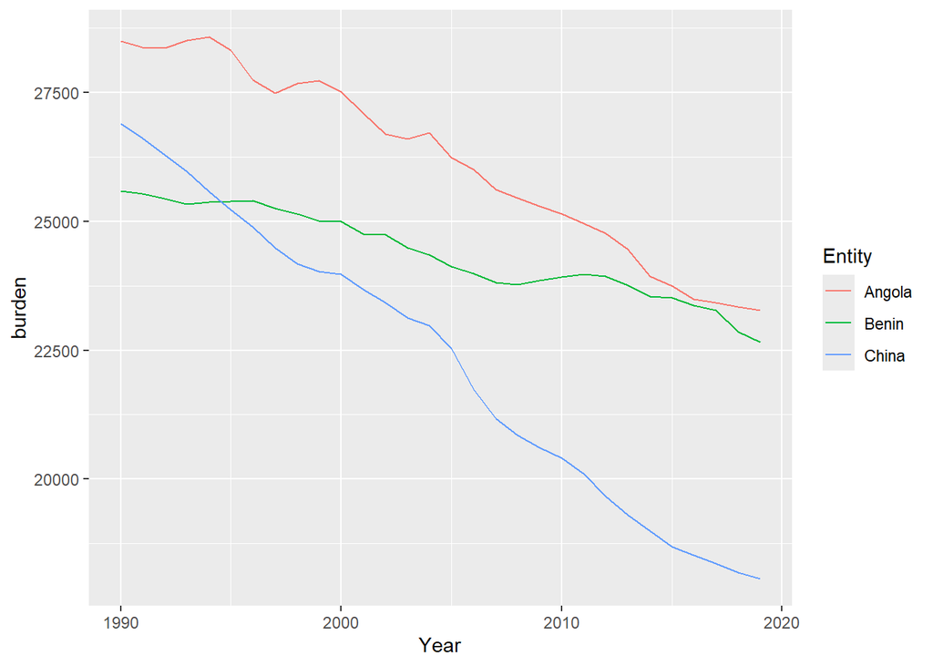

## Summary of NCD Burden Findings

We observed that all three countries had a high burden of non-communicable diseases in the 1990s. However, over the years, we observed a decrease in the burden of non-communicable diseases in all these countries. That being said, China experienced a more pronounced decline compared with Angola and Benin.

## Attribution

This section was completed by **Fara**

The link to the group’s GitHub repository is *https://github.com/bkabaseleilunga-bit/rmc_week_02_workshop*